# Proteomics

Marc A.T. Teunis; Rene Van de Ploeg; Robert Jan Veldman

2018-12-06

Steps in this Demo Case:

- Filter the data for experiment 142 to 149: Different cells, Affinity Matrix (Kinobeads)
- Group the data for each Accession number (`protein` variable) and experiment
- Summarize the `spectrum_count` data for each protein
- Get cell line information from a different file to convert the `experiment_id`s to cell lines names.
- Create a heatmap using the `pheatmap` package. Plot the cell-type on the X-axis and the protein-names on the y-axis of your heatmaps.

```r
## defines the root of the project for later use
require("rprojroot") || utils::install.packages("rprojroot")
```

```
## [1] TRUE
```

```r
library(rprojroot)
root <- find_root_file(criterion = is_rstudio_project)
```

```r
library(tidyverse)
```

**Write an Rmd file, containing code chunks (if applicable) and answer all the questions below. Store the file in a folder called: “./answers_exercises” in your course project folder. Give this file the same name as the title of the current Rmd file**

## Literature

The case used in this exercise is from Bantscheff et al., 2007 (see zip-archive “4_001_qcproteomics_literature.zip”)

## Load the data

```r
#nbt1328_S3 <- readr::read_delim(file = file.path(root, "data", "nbt1328-S3.txt"),
#                                delim = "\t", skip = 2)
nbt1328_S2 <- readr::read_delim(file = file.path(root, "data", "nbt1328-S2.txt"),
                                delim = "\t", skip = 4)

head(nbt1328_S2)
```

```
## # A tibble: 6 x 7
##   `IPI acc. no.` Protein Kinase `Experiment Id` `Spectrum Count`
##   <chr>          <chr>   <chr>            <int>            <int>
## 1 IPI00292228    GSK3A   GSK3A                1                3
## 2 IPI00296337    PRKDC   DNAPK                1                2
## 3 IPI00296337    PRKDC   DNAPK                1                1
## 4 IPI00292228    GSK3A   GSK3A                1                2
## 5 IPI00296337    PRKDC   DNAPK                1                1
## 6 IPI00430291    CAMK2D  CaMK2d               1                1
## # ... with 2 more variables: `Peptide Sequence` <chr>, `Maximum Mascot
## #   Ions Score` <int>
```

```r
#head(nbt1328_S3)
```

## Inspect the data

Answer the following questions:

1A) How many obeservations does the file “nbt1328-S2.txt” have?

1B) How many unique proteins are their in both datasets? You can use the command `distinct` or `unique` here

**ANSWER**

2A) What does the following code do? Why?

```r
names(nbt1328_S2) <-
  stringr::str_replace_all(names(nbt1328_S2),
                           pattern = " ",
                           replacement = "_") %>%
  tolower()


names(nbt1328_S2) <-
  stringr::str_replace_all(names(nbt1328_S2),
                           pattern = "\\.",
                           replacement = "")

names(nbt1328_S2)
```

```
## [1] "ipi_acc_no"                "protein"
## [3] "kinase"                    "experiment_id"
## [5] "spectrum_count"            "peptide_sequence"
## [7] "maximum_mascot_ions_score"
```

2B) Select the following variables from the dataframe `nbt1328_S2`

- `ipi_acc_no`
- `protein`
- `kinase`
- `experiment_id`
- `spectrum_count`

**ANSWER**

2C) Which variables are numeric? Do you need to change the class of these variables? Use (`head`, or the `class` command)

**ANSWER**

## Summarize the data

Summarize the data for the total of experiments in `nbt1328_s2` running the following code: Discuss with your neighbour the code steps, do you understand what is happening? I will pick somebody to expplain, so be prepared!

```r
nbt1328_S2
```

```
## # A tibble: 117,937 x 7
##    ipi_acc_no protein kinase experiment_id spectrum_count peptide_sequence
##    <chr>      <chr>   <chr>          <int>          <int> <chr>
##  1 IPI002922… GSK3A   GSK3A              1              3 LTIPILYVK
##  2 IPI002963… PRKDC   DNAPK              1              2 AQEPESGLSEETQVK
##  3 IPI002963… PRKDC   DNAPK              1              1 AYVPALQMAFK
##  4 IPI002922… GSK3A   GSK3A              1              2 VYMYQLFR
##  5 IPI002963… PRKDC   DNAPK              1              1 EFPPGTPR
##  6 IPI004302… CAMK2D  CaMK2d             1              1 FTDEYQLFEELGK
##  7 IPI002963… PRKDC   DNAPK              1              3 QLFSSLFSGILK
##  8 IPI002161… GSK3B   GSK3B              1              3 VIGNGSFGVVYQAK
##  9 IPI002963… PRKDC   DNAPK              1              1 LPSNTLDR
## 10 IPI002963… PRKDC   DNAPK              1              1 MYAALGDPK
## # ... with 117,927 more rows, and 1 more variable:
## #   maximum_mascot_ions_score <int>
```

```r
names(nbt1328_S2)
```

```
## [1] "ipi_acc_no"                "protein"
## [3] "kinase"                    "experiment_id"
## [5] "spectrum_count"            "peptide_sequence"
## [7] "maximum_mascot_ions_score"
```

```r
## check which experiment is available
#levels(as.factor(nbt1328_S2$experiment_id))
#nbt1328_S2$experiment_id

experiments <- c(142:149) %>% as.character()

nbt1328_S2_summary <- nbt1328_S2 %>%
  # filter for experiments:
  dplyr::filter(as.character(experiment_id) %in% as.character(experiments)) %>%
  group_by(ipi_acc_no, protein, experiment_id) %>%
  summarise(sum_counts = sum(as.numeric(spectrum_count)))

nbt1328_S2_summary <- nbt1328_S2_summary %>% na.omit()
nbt1328_S2_summary
```

```
## # A tibble: 8,211 x 4
## # Groups:   ipi_acc_no, protein [2,979]
##    ipi_acc_no  protein                            experiment_id sum_counts
##    <chr>       <chr>                                      <int>      <dbl>
##  1 CZB00000043 BCR-ABL p210                                 142          9
##  2 CZB00000043 BCR-ABL p210                                 143         10
##  3 CZB00000043 BCR-ABL p210                                 144         38
##  4 CZB00000043 BCR-ABL p210                                 145          9
##  5 CZB00000043 BCR-ABL p210                                 146        208
##  6 CZB00000043 BCR-ABL p210                                 148       5159
##  7 CZB00000043 BCR-ABL p210                                 149        197
##  8 CZB00000100 14-3-3 zeta  human (IPI00021263.1)           144         26
##  9 CZB00000100 14-3-3 zeta  human (IPI00021263.1)           145        108
## 10 CZB00000100 14-3-3 zeta  human (IPI00021263.1)           146         88
## # ... with 8,201 more rows
```

3A) Replicating the following figure (partly:) For the following figure we will use only the `complete cases` for the data in table `nbt1382_s2`. This means only data that is available for each experiment (cell type 142-149, see file “data/labellings_qcproteomics.txt”). This will partly recreate figure 1 of the paper by Bantscheff et al., 2007.

Figure 1 from the paper:

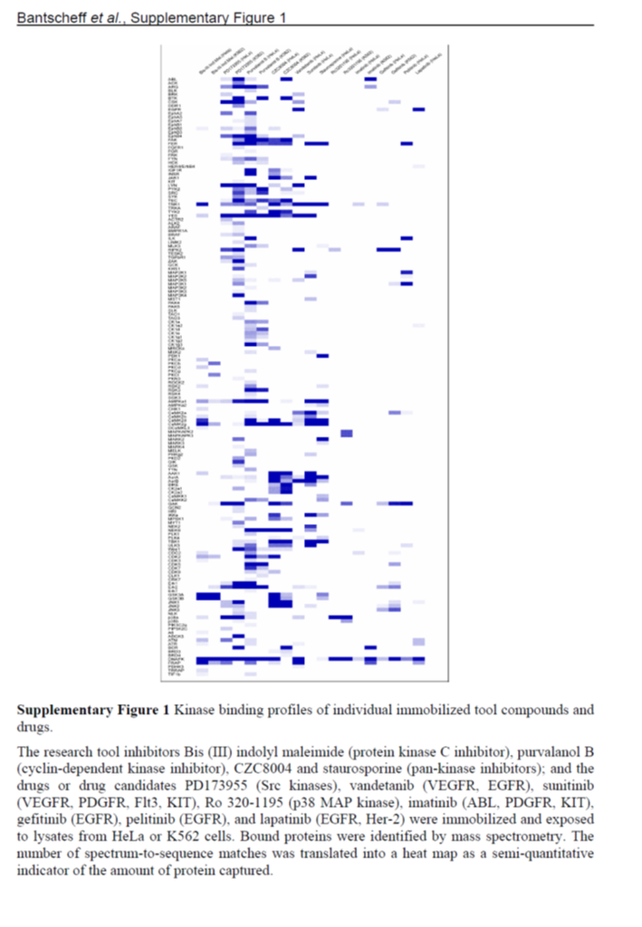

```r
knitr::include_graphics(file.path(root, "images", "bantscheff_figure_1.png"))
```

## An exploratory plot

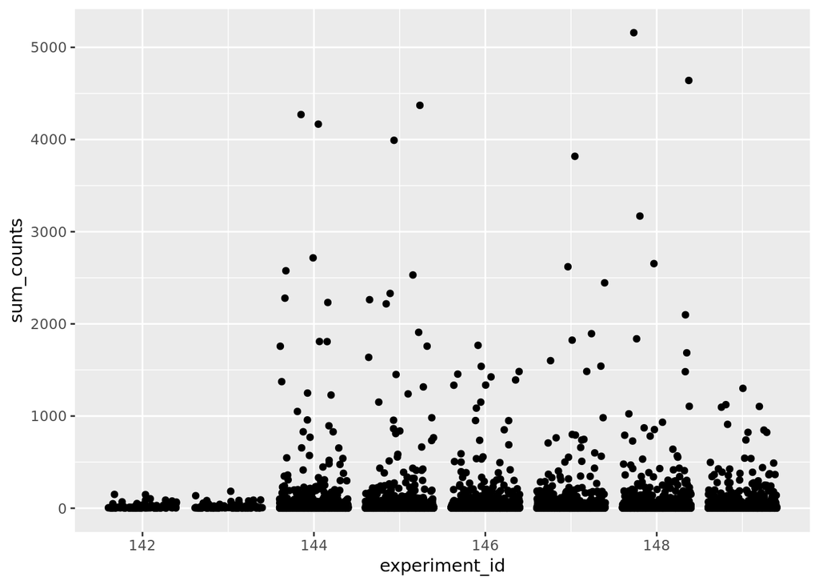

```r
nbt1328_S2_summary %>%
ggplot(aes(y = sum_counts, x = experiment_id)) +
  geom_point(position = "jitter")
```

## Add labellings to data

```r
## load data
labelling <-
  read_delim(file.path(root, "data", "labellings_qcproteomics.txt"),
             delim = " ")

## select fist two columns
names(labelling)
```

```
## [1] "experiment"                   "cell_line"
## [3] "affinitymatrix"               "free_compound_profiled"
## [5] "application_of_free_compound"
```

```r
labelling <- labelling[, c(1:5)]
head(labelling)
```

```
## # A tibble: 6 x 5
##   experiment cell_line affinitymatrix free_compound_pr… application_of_fr…
##        <int> <chr>     <chr>          <chr>             <chr>
## 1        122 HeLa      Purvalanol     B                 none
## 2        123 HeLa      Purvalanol     B                 none
## 3        124 HeLa      Purvalanol     B                 none
## 4        125 HeLa      Purvalanol     B                 none
## 5        126 HeLa      Purvalanol     B                 none
## 6        127 HeLa      Purvalanol     B                 none
```

```r
names(labelling) <-
  c("experiment_id", "cell_line", "method", "chemical", "profile")
head(labelling)
```

```
## # A tibble: 6 x 5
##   experiment_id cell_line method     chemical profile
##           <int> <chr>     <chr>      <chr>    <chr>
## 1           122 HeLa      Purvalanol B        none
## 2           123 HeLa      Purvalanol B        none
## 3           124 HeLa      Purvalanol B        none
## 4           125 HeLa      Purvalanol B        none
## 5           126 HeLa      Purvalanol B        none
## 6           127 HeLa      Purvalanol B        none
```

```r
labelling
```

```
## # A tibble: 60 x 5
##    experiment_id cell_line method     chemical profile
##            <int> <chr>     <chr>      <chr>    <chr>
##  1           122 HeLa      Purvalanol B        none
##  2           123 HeLa      Purvalanol B        none
##  3           124 HeLa      Purvalanol B        none
##  4           125 HeLa      Purvalanol B        none
##  5           126 HeLa      Purvalanol B        none
##  6           127 HeLa      Purvalanol B        none
##  7           128 HeLa      Purvalanol B        none
##  8           129 HeLa      Purvalanol B        none
##  9           130 HeLa      Purvalanol B        none
## 10           131 HeLa      Purvalanol B        none
## # ... with 50 more rows
```

```r
## select labelling for heatmap below
labels <- labelling %>%
  dplyr::filter(experiment_id %in% experiments)

labels <- labels$cell_line

labels
```

```
## [1] "Ramos"    "Ramos"    "Ramos"    "Ramos"    "HeLa"     "Jurkat"
## [7] "K562"     "Placenta"
```

## Prepare data

```r
#install.packages("gplots")
library(gplots)
library(tidyverse)


## join with labelling
data <- nbt1328_S2_summary

#labelling$experiment_id <- as.character(labelling$experiment_id)
#data <- dplyr::left_join(data, labelling, by = "experiment_id")

## wide format
data <- data %>%
  spread(key = experiment_id, value = sum_counts) %>%
      as.data.frame()

## isolate ck1a
ck1a <- data %>%
  select(`146`, ipi_acc_no, protein) %>%
  dplyr::filter(ipi_acc_no == "IPI00448798")

## remove NAs
data <- data %>%
  na.omit()

## Check for duplicate observations
ind <- duplicated(data$ipi_acc_no)
data <- data[!ind,]
data %>% head(2)
```

```
##     ipi_acc_no protein 142 143 144 145 146 147 148 149
## 19 IPI00000685    CDK7   6   5  73  83  73  58 102  16
## 32 IPI00000878     TEC   4  10 159 151 127  39 430  32
```

## Create matrix from the summary data

```r
rnames <- data[,2]                            # assign labels in column 1 to "rnames"
unique(rnames)
```

```
##  [1] "CDK7"     "TEC"      "MAPK14"   "MAPK1"    "HSPA8"    "CSNK2B"
##  [7] "JAK1"     "TUBB"     "MAP3K1"   "CSK"      "PRKAB2"   "PAK4"
## [13] "CSNK2A1"  "MAPK3"    "DCK"      "CSNK2A2"  "RPS6KA3"  "CDK5"
## [19] "MAPK8"    "WEE1"     "ANP32A"   "IKBKE"    "FER"      "PTK2B"
## [25] "CDK2"     "CAMK2G"   "GSK3B"    "FYN"      "PRKAB1"   "YWHAG"
## [31] "EIF3S1"   "LIMK1"    "GSK3A"    "MIF"      "TBK1"     "MNAT1"
## [37] "LYN"      "GAK"      "TANK"     "CAD"      "NEK9"     "MAPK9"
## [43] "BRAF"     "PRKCD"    "ABL2"     "TUBA6"    "LCK"      "PRKAA1"
## [49] "CAMK2D"   "TNK2"     "KIAA0528" "RPS6KA1"  "MAP3K2"   "MARK2"
## [55] "KIAA0999"
```

```r
data <- as.matrix(data[,3:ncol(data)])  # transform column 2-5 into a matrix
row.names(data) <- rnames                  # assign row names
head(data)
```

```
##        142 143  144  145  146 147  148  149
## CDK7     6   5   73   83   73  58  102   16
## TEC      4  10  159  151  127  39  430   32
## MAPK14  88  85 1373 1451 1336 982 1106 1096
## MAPK1   51  48 1249 1316 1086 740 3170 1124
## HSPA8    4   3  214  181  335 332  204   91
## CSNK2B  12  15  132  115   40 136  101   62
```

## Create heatmap

**Discuss the code below with your neighbour!**

Did we succeed to reproduce (partly) the heatmap (figure 1) from the paper Bantscheff et al., 2007?

For the heatmap we use the package `pheatmap`. There are a lot of other packages in R/Bionconductor you could use.

```r
?pheatmap
```

```
## No documentation for 'pheatmap' in specified packages and libraries:
## you could try '??pheatmap'
```

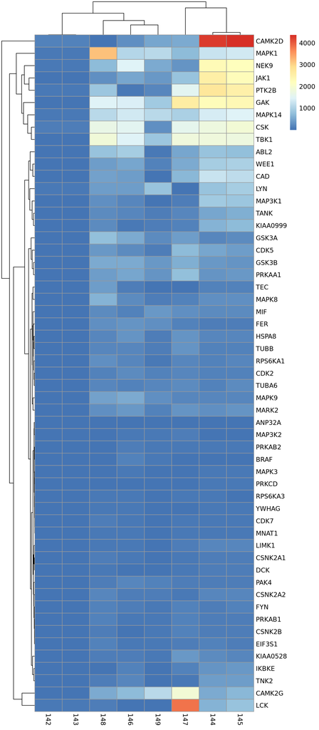

```r
#install.packages("pheatmap")
library(pheatmap)
pheatmap::pheatmap(data)
```

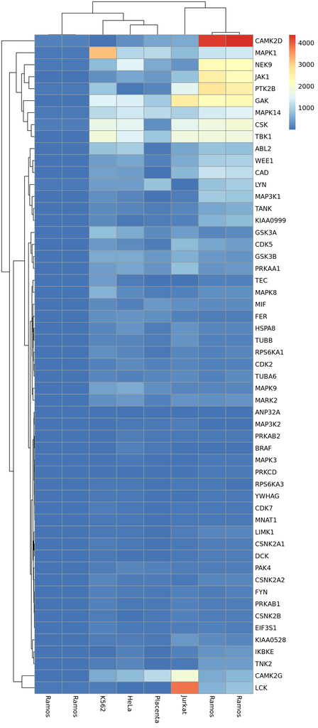

```r
## add labels on x-axis
colnames(data) <- c(labels)
pheatmap::pheatmap(data)
```

```r
## store heatmap on disk, you will find the resulting picture in the root of your project
png(filename = "heatmap_qcproteomics.png", width = 10, height = 22, units = "cm", res = 300)
pheatmap::pheatmap(data)
dev.off()
```

## Customizing `pheatmap` colours

```r
RColorBrewer::display.brewer.all()

# creates a own color palette from red to green
my_palette_1 <- colorRampPalette(c("red", "yellow", "green"))(n = 299)
my_palette_2 <- colorRampPalette(c("black", "yellow", "green"))(n = 299)
my_palette_3 <- colorRampPalette(c("red", "black", "green"))(n = 299)

my_palette_4 <- RColorBrewer::brewer.pal(n = 11, name = "PRGn")

pheatmap::pheatmap(data, color = my_palette_1)
pheatmap::pheatmap(data, color = my_palette_2)
pheatmap::pheatmap(data, color = my_palette_3)
pheatmap::pheatmap(data, color = my_palette_4)

# creates a 5 x 5 inch image
png("let_s_go_crazy_heatmap.png",
  width = 5*300,        # 5 x 300 pixels
  height = 12*300,
  res = 300,            # 300 pixels per inch
  pointsize = 8)        # smaller font size

pheatmap::pheatmap(data, color = my_palette_4)

dev.off()
```

**BONUS QUESTION!**

4. Generate at leat three exploratory data analysis graphs of this data-set, you are free to choose what to plot here! **Work together with your neighbour on this!!**

Review the material from the lecture and exercise “Visualizations” and/or refer to the corresponding chapter in “R for Data Science” http://r4ds.had.co.nz/data-visualisation.html